# HW 07

STA 198 Spring 2020 (Jiang)

Due: Monday, July 20, 2020 at 11:59p

# Data

- `hglev`: mercury levels (mg/g) in hair
- `sex`: sex of the resident (M = male; F = female)
- `fishmlwk`: average number of meals with fish consumed per week

They have fit the following two models:

| Model 1 | Estimate | Std. Error | t-value | p-value |
| --- | --- | --- | --- | --- |
| Intercept | 2.6816 | 0.3841 | 6.98 | <0.0001 |
| fishmlwk | 0.1676 | 0.0457 | 3.67 | 0.0004 |

| Model 2 | Estimate | Std. Error | t-value | p-value |
| --- | --- | --- | --- | --- |
| Intercept | 1.5615 | 0.5932 | 2.63 | 0.0095 |
| sex == M | 0.0901 | 0.0350 | 2.58 | 0.0111 |

The R$^2$ for Model 1 was 0.09 and the R$^2$ for Model 2 was 0.04.

To interpret Model 2, if the resident’s sex was equal to “M,” then they get a 1. Otherwise, they get a 0.

1. **3 points** What is the Pearson correlation between the number of fish meals consumed per week and total hair mercury levels? If we cannot tell from the output provided, please state so and explain.
2. **3 points** What is the interpretation of the intercept term in Model 1? Is this a meaningful quantity to estimate? Explain.
3. **3 points** What is the interpretation of the `fishmelwk` term in Model 1? Is this a meaningful quantity to estimate? Explain.
4. **3 points** What is the interpretation of the intercept term in Model 2? Is this a meaningful quantity to estimate? Explain.
5. **3 points** What is the interpretation of the `slope` term in Model 2? Is this a meaningful quantity to estimate? Explain.
6. **4 points** Write out model 1 and model 2 in symbols, being sure to define any notation you introduce.
7. **3 points** Using these models, what is the predicted total mercury level for a resident who eats 8 fish meals per week? (if we do not have enough information, explain why)
8. **2 points** Using these models, what is the predicted total mercury level for a female resident who eats 3 fish meals per week? (if we do not have enough information, explain why)

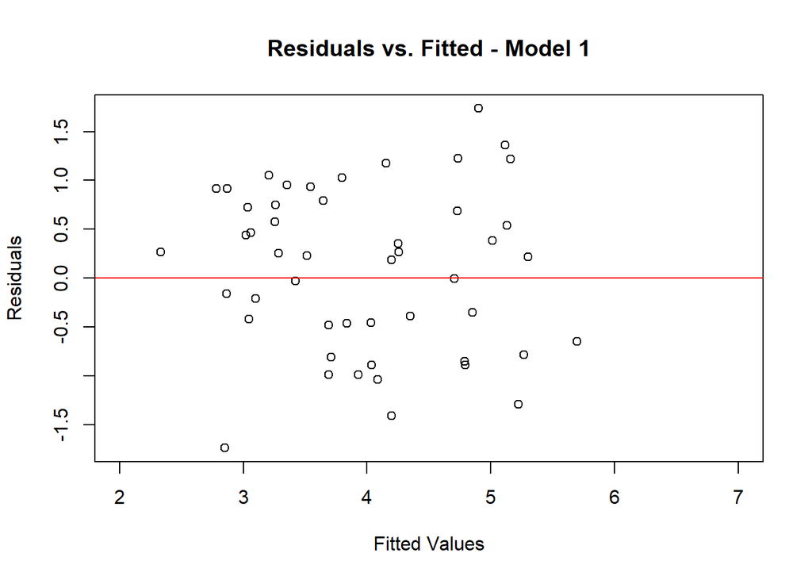